# M05: Reflection on Ch09 (Evaluation)

- Show All Code
- Hide All Code
- View Source

Author

Sora Hosoda

Published

July 7, 2026

# Learning Objectives

By the end of this notebook you will be able to:

1. Choose appropriate regression and classification metrics with `yardstick`
2. Read and interpret a confusion matrix, sensitivity, specificity, and ROC/AUC
3. Explain *why* evaluating a model on its own training data is overly optimistic (resubstitution)
4. Build cross-validation folds with `vfold_cv()` and other resampling schemes with `rsample`
5. Use `fit_resamples()` to get a trustworthy estimate of model performance
6. Connect resampled performance back to the metrics from Section 1

> **Textbook reference:** *Tidy Modeling with R* (TMWR), Chapters 9 & 10 (https://www.tmwr.org/performance, https://www.tmwr.org/resampling)

# 1 Setup

```r
library(tidymodels) # umbrella: rsample, recipes, parsnip, workflows, yardstick
library(tidyverse)
library(gt) # pretty tables
library(patchwork) # combine plots

tidymodels_prefer() # resolve function-name conflicts
set.seed(2026)
```

# 2 The Marketing Dataset

We return to our synthetic **direct-mail** dataset from Week 2. Each row is one prospect; the outcome is whether they **responded** (bought).

```r
# ── Synthetic direct-mail dataset (same generator as Week 2 / Week 7) ─────────
set.seed(123)
n <- 3000

mail_data <- tibble(
  customer_id = paste0("C", str_pad(1:n, 5, pad = "0")),
  age = round(rnorm(n, mean = 45, sd = 12)),
  income = round(rlnorm(n, meanlog = 10.8, sdlog = 0.6)), # right-skewed
  recency_days = round(rexp(n, rate = 1 / 60)), # days since last purchase
  freq_12mo = rpois(n, lambda = 3), # purchases in 12 months
  avg_order_amt = round(rlnorm(n, meanlog = 4.2, sdlog = 0.5), 2),
  channel = sample(
    c("email", "direct_mail", "digital"),
    n,
    replace = TRUE,
    prob = c(0.5, 0.3, 0.2)
  ),
  region = sample(
    c("West", "South", "Midwest", "Northeast"),
    n,
    replace = TRUE
  ),
  loyalty_tier = factor(
    sample(
      c("Bronze", "Silver", "Gold", "Platinum"),
      n,
      replace = TRUE,
      prob = c(0.4, 0.3, 0.2, 0.1)
    ),
    levels = c("Bronze", "Silver", "Gold", "Platinum")
  ),
  responded = rbinom(
    n,
    1,
    prob = plogis(
      -3 +
        0.02 * (age - 45) +
        0.3 * log(income / 50000) +
        0.1 * freq_12mo -
        0.005 * recency_days
    )
  )
) |>
  mutate(
    income = if_else(runif(n) < 0.08, NA_real_, income),
    avg_order_amt = if_else(runif(n) < 0.05, NA_real_, avg_order_amt),
    responded = factor(responded, levels = c(1, 0), labels = c("yes", "no"))
  )
# introduce ~8 % missingness in income and avg_order_amt

glimpse(mail_data)
```

```
Rows: 3,000
Columns: 10
$ customer_id   <chr> "C00001", "C00002", "C00003", "C00004", "C00005", "C0000…
$ age           <dbl> 38, 42, 64, 46, 47, 66, 51, 30, 37, 40, 60, 49, 50, 46, …
$ income        <dbl> 44793, 40269, 20560, 32261, 233070, 47933, 84804, 43883,…
$ recency_days  <dbl> 103, 102, 27, 115, 47, 106, 4, 62, 13, 21, 139, 100, 9, …
$ freq_12mo     <int> 4, 3, 0, 3, 1, 3, 5, 2, 1, 6, 1, 3, 3, 3, 6, 1, 1, 1, 6,…
$ avg_order_amt <dbl> 80.19, NA, 54.80, 46.49, 64.86, 78.43, 39.45, NA, 68.26,…
$ channel       <chr> "email", "digital", "digital", "email", "digital", "dire…
$ region        <chr> "West", "South", "Northeast", "Northeast", "Midwest", "W…
$ loyalty_tier  <fct> Bronze, Bronze, Bronze, Bronze, Gold, Silver, Bronze, Br…
$ responded     <fct> no, no, yes, no, yes, yes, no, no, no, no, no, no, no, n…
```

We also derive a **continuous** target — `order_value_next` — so we have a realistic stand-in for regression metrics in Section 1. Think of this as “expected next-order revenue,” something a marketer might forecast for budget planning.

```r
mail_data <- mail_data |>
  mutate(
    order_value_next = round(
      pmax(
        0,
        15 +
          0.0006 * coalesce(income, median(income, na.rm = TRUE)) +
          4 * freq_12mo -
          0.05 * recency_days +
          rnorm(n, 0, 20)
      ),
      2
    )
  )

mail_data |> select(customer_id, order_value_next) |> head()
```

| customer_id | order_value_next |
| --- | --- |
| C00001 | 77.63 |
| C00002 | 45.64 |
| C00003 | 9.48 |
| C00004 | 24.11 |
| C00005 | 163.57 |
| C00006 | 60.17 |

**Note**

**Marketing context.** `responded` (yes/no) is our **classification** target — will this prospect respond to the next campaign? `order_value_next` is our **regression** target — how much will they spend on their next order? Both are common marketing prediction tasks, and TMWR Chapter 9 covers metrics for each.

# 3 Train/Test Split and a Reference Model

Before we can evaluate anything, we need a fitted model. We reuse the same split-then-recipe workflow from Week 2.

```r
set.seed(617)
mail_split <- initial_split(mail_data, prop = 0.80, strata = responded)
mail_train <- training(mail_split)
mail_test <- testing(mail_split)

cat("Training rows:", nrow(mail_train), "\n")
```

```
Training rows: 2400
```

```r
cat("Test rows    :", nrow(mail_test), "\n")
```

```
Test rows    : 600
```

```r
mail_rec <- recipe(
  responded ~ age +
    income +
    recency_days +
    freq_12mo +
    avg_order_amt +
    channel +
    region +
    loyalty_tier,
  data = mail_train
) |>
  step_impute_median(all_numeric_predictors()) |>
  step_log(income, avg_order_amt, recency_days, base = 10, offset = 1) |>
  step_normalize(all_numeric_predictors()) |>
  step_dummy(all_nominal_predictors()) |>
  step_zv(all_predictors())

lr_spec <- logistic_reg(penalty = 0.01, mixture = 1) |> # Lasso
  set_engine("glmnet") |>
  set_mode("classification")

mail_wf <- workflow() |>
  add_recipe(mail_rec) |>
  add_model(lr_spec)

mail_fit <- fit(mail_wf, data = mail_train)
```

```r
test_preds <- augment(mail_fit, new_data = mail_test)
test_preds |>
  select(customer_id, responded, .pred_class, .pred_yes, .pred_no) |>
  head()
```

| customer_id | responded | .pred_class | .pred_yes | .pred_no |
| --- | --- | --- | --- | --- |
| C00001 | no | no | 0.04425404 | 0.9557460 |
| C00002 | no | no | 0.04397476 | 0.9560252 |
| C00014 | no | no | 0.04612421 | 0.9538758 |
| C00015 | no | no | 0.04929630 | 0.9507037 |
| C00017 | no | no | 0.04394313 | 0.9560569 |
| C00030 | no | no | 0.05161806 | 0.9483819 |

# 4 **Part 1** — Judging Model Effectiveness (TMWR Ch. 9)

- A fitted model is only useful if we can say, in concrete numeric terms, *how good* its predictions are.
- `yardstick` is the tidymodels package for this — every metric function takes `truth` and an `estimate`/probability column and returns a tidy one-row tibble.

## 4.1 Why Metrics, Not Just “It Fit”

**Important**

**There is no single “best” metric.** The right metric depends on the business question. For a churn model, missing a true churner (low **sensitivity**) might be far more costly than flagging a loyal customer by mistake (low **specificity**). Always pick metrics that match the marketing decision the model supports.

## 4.2 Regression Metrics

We don’t have a regression *model* yet in this notebook, so we’ll fit one quickly — predicting `order_value_next` from a few predictors — purely to demonstrate the metrics.

```r
reg_spec <- linear_reg() |>
  set_engine("lm")

reg_rec <- recipe(
  order_value_next ~ income + freq_12mo + recency_days,
  data = mail_train
) |>
  step_impute_median(all_numeric_predictors()) |>
  step_normalize(all_numeric_predictors())

reg_wf <- workflow() |> add_recipe(reg_rec) |> add_model(reg_spec)
reg_fit <- fit(reg_wf, data = mail_train)

reg_preds <- augment(reg_fit, new_data = mail_test)
reg_preds |> select(customer_id, order_value_next, .pred, .resid) |> head()
```

| customer_id | order_value_next | .pred | .resid |
| --- | --- | --- | --- |
| C00001 | 77.63 | 52.66854 | 24.96146 |
| C00002 | 45.64 | 45.90605 | -0.26605 |
| C00014 | 60.98 | 77.50545 | -16.52545 |
| C00015 | 81.32 | 54.50260 | 26.81740 |
| C00017 | 15.85 | 49.03126 | -33.18126 |
| C00030 | 39.12 | 66.79839 | -27.67839 |

```r
reg_metrics <- metric_set(rmse, rsq, mae)

reg_preds |>
  reg_metrics(truth = order_value_next, estimate = .pred)
```

| .metric | .estimator | .estimate |
| --- | --- | --- |
| rmse | standard | 20.0193095 |
| rsq | standard | 0.5659006 |
| mae | standard | 16.1059669 |

### 4.2.1 **RMSE** (root mean squared error):

Average prediction error, in the *original units* (dollars here). Penalizes large errors more heavily because errors are squared before averaging.

**NoteRMSE Formula**

$$RMSE = \sqrt{\frac{1}{n}\sum_{i=1}^{n}(y_i - \hat{y}_i)^2}$$

- Where
  - $n$ is the number of observations,
  - $y_i$ is the actual value, and
  - $\hat{y}_i$ is the predicted value.
  - $(y_i - \hat{y}_i)$ = the residual (prediction error) for observation $i$
- RMSE is in the **same units as the outcome variable** — dollars, in our case — making it directly interpretable.

### 4.2.2 **R² (rsq)**:

- Proportion of variance in the outcome explained by the model.
- Ranges roughly 0–1; higher is better.
- Useful for communicating “how much of next-order value our model explains” to stakeholders.

**NoteR-Squared formula**

$$R^2 = 1 - \frac{\sum_{i=1}^{n}(y_i - \hat{y}_i)^2}{\sum_{i=1}^{n}(y_i - \bar{y})^2}$$

Where:

- $y_i$ = actual value for observation $i$
- $\hat{y}_i$ = predicted value for observation $i$
- $\bar{y}$ = mean of all actual values
- $\sum_{i=1}^{n}(y_i - \hat{y}_i)^2$ = total unexplained variation (residual sum of squares)
- $\sum_{i=1}^{n}(y_i - \bar{y})^2$ = total variation in the outcome (total sum of squares)

### 4.2.3 **MAE** (mean absolute error):

- Average absolute error, less sensitive to outliers than RMSE.
- If a few extreme spenders are skewing RMSE, compare it against MAE.

**NoteMAE Formula**

$$MAE = \frac{1}{n}\sum_{i=1}^{n}|y_i - \hat{y}_i|$$

Where:

- $n$ = number of observations
- $y_i$ = actual value for observation $i$
- $\hat{y}_i$ = predicted value for observation $i$
- $|y_i - \hat{y}_i|$ = absolute prediction error for observation $i$

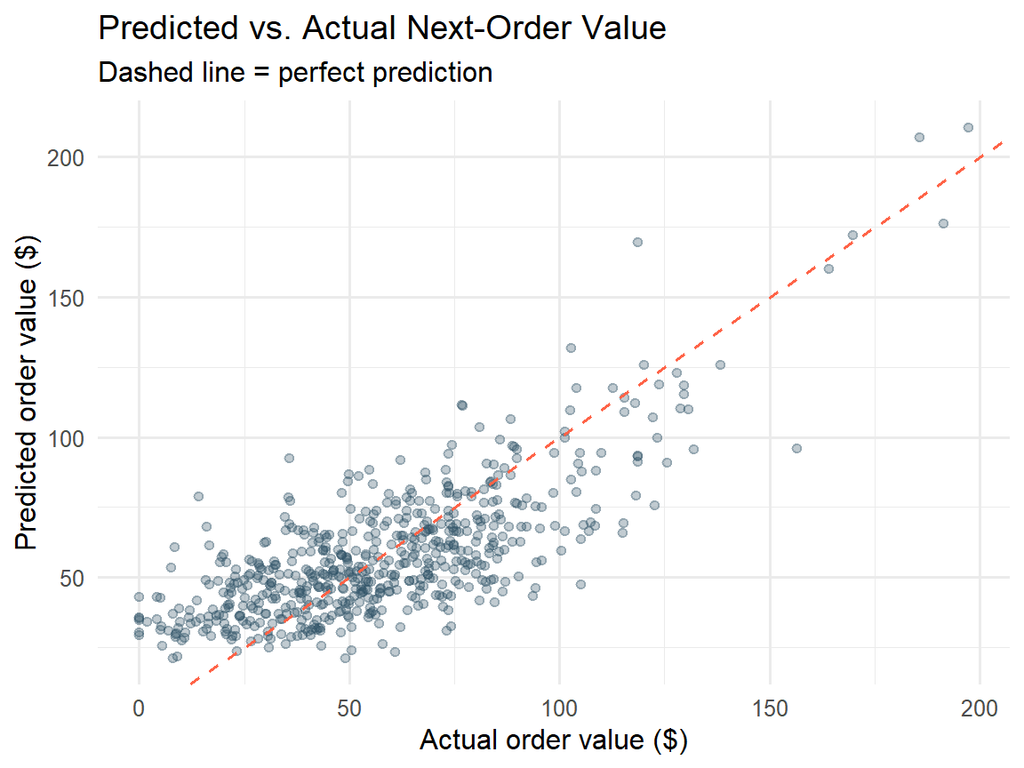

```r
ggplot(reg_preds, aes(x = order_value_next, y = .pred)) +
  geom_point(alpha = 0.3, color = "#2E5266") +
  geom_abline(slope = 1, intercept = 0, linetype = "dashed", color = "tomato") +
  labs(
    title = "Predicted vs. Actual Next-Order Value",
    subtitle = "Dashed line = perfect prediction",
    x = "Actual order value ($)",
    y = "Predicted order value ($)"
  ) +
  theme_minimal(base_size = 12)
```

## 4.3 Binary Classification Metrics

Back to our `responded` (yes/no) model. The starting point for classification metrics is the **confusion matrix**: a 2×2 table of predicted vs. actual class.

```r
conf_mat(test_preds, truth = responded, estimate = .pred_class)
```

```
          Truth
Prediction yes  no
       yes   0   0
       no   31 569
```

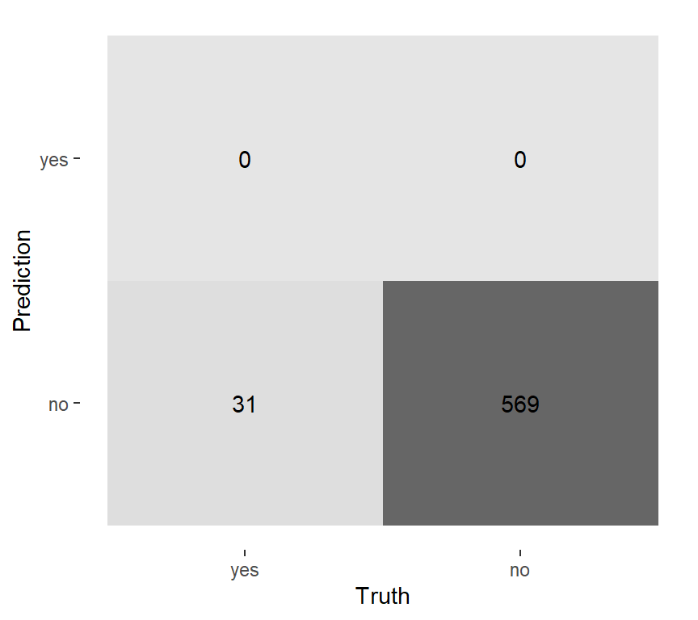

```r
conf_mat(test_preds, truth = responded, estimate = .pred_class) |>
  autoplot(type = "heatmap")
```

**NoteFrom Confusion Matrix to Metrics**

| Metric | Formula (informal) | Marketing question it answers |
| --- | --- | --- |
| **Sensitivity** (recall) | TP / (TP + FN) | Of customers who *would* respond, how many did we catch? |
| **Specificity** | TN / (TN + FP) | Of customers who *wouldn’t* respond, how many did we correctly skip? |
| **Precision (PPV)** | TP / (TP + FP) | Of customers we targeted, how many actually responded? |
| **Accuracy** | (TP + TN) / Total | Overall, how often is the model right? *(misleading with rare classes — see warning below)* |

### 4.3.1 Sensitivity (Recall)

**NoteDetails**

$$\text{Sensitivity} = \frac{TP}{TP + FN}$$

Where:

- $TP$ = true positives — customers who responded and were correctly predicted to respond
- $FN$ = false negatives — customers who responded but were incorrectly predicted not to respond
- $TP + FN$ = total number of actual responders

### 4.3.2 Specificity

**NoteDetails**

$$\text{Specificity} = \frac{TN}{TN + FP}$$

Where:

- $TN$ = true negatives — customers who did not respond and were correctly predicted not to respond
- $FP$ = false positives — customers who did not respond but were incorrectly predicted to respond
- $TN + FP$ = total number of actual non-responders

### 4.3.3 Precision (PPV)

**NoteDetails**

$$\text{Precision} = \frac{TP}{TP + FP}$$

Where:

- $TP$ = true positives — correctly predicted responders
- $FP$ = false positives — non-responders incorrectly predicted as responders
- $TP + FP$ = total number of customers predicted to respond

### 4.3.4 Accuracy

**NoteDetails**

$$\text{Accuracy} = \frac{TP + TN}{TP + TN + FP + FN}$$

Where:

- $TP$ = true positives
- $TN$ = true negatives
- $FP$ = false positives
- $FN$ = false negatives
- $TP + TN + FP + FN$ = total number of observations

### 4.3.5 F1 Score

**NoteDetails**

$$F_1 = 2 \times \frac{\text{Precision} \times \text{Sensitivity}}{\text{Precision} + \text{Sensitivity}}$$

Where:

- $\text{Precision} = \frac{TP}{TP + FP}$
- $\text{Sensitivity} = \frac{TP}{TP + FN}$
- $F_1$ is the harmonic mean of precision and sensitivity — useful when both matter equally and the classes are imbalanced

```r
class_metrics <- metric_set(accuracy, sens, spec, precision, f_meas)

test_preds |>
  class_metrics(truth = responded, estimate = .pred_class)
```

| .metric | .estimator | .estimate |
| --- | --- | --- |
| accuracy | binary | 0.9483333 |
| sens | binary | 0.0000000 |
| spec | binary | 1.0000000 |
| precision | binary | NA |
| f_meas | binary | NA |

**Warning**

**Accuracy is dangerous with imbalanced classes.** Direct-mail response rates are often only 3–8%. A model that predicts “no” for *everyone* could still score 95%+ accuracy while being completely useless for targeting. Always check sensitivity/specificity alongside accuracy — this is exactly the kind of trap a stakeholder unfamiliar with the data could fall into.

### 4.3.6 ROC Curve and AUC

Sensitivity and specificity above were computed at a single classification threshold (0.5 by default). The **ROC curve** shows the sensitivity/specificity trade-off across *every possible* threshold, and **AUC** summarizes the whole curve in one number.

```r
roc_data <- test_preds |>
  roc_curve(truth = responded, .pred_yes)

auc_val <- test_preds |>
  roc_auc(truth = responded, .pred_yes) |>
  pull(.estimate)
```

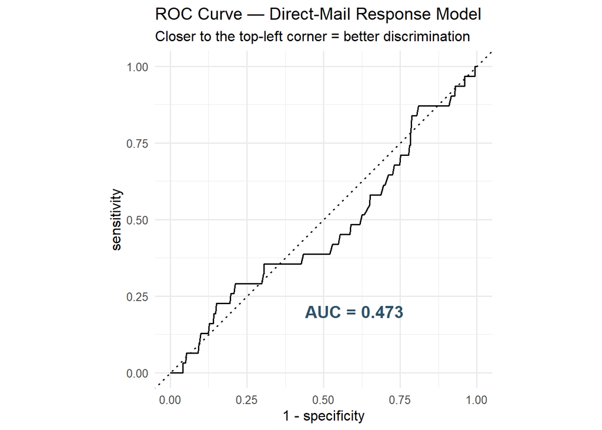

```r
autoplot(roc_data) +
  annotate(
    "text",
    x = 0.6,
    y = 0.2,
    label = paste0("AUC = ", round(auc_val, 3)),
    size = 5,
    color = "#2E5266",
    fontface = "bold"
  ) +
  labs(
    title = "ROC Curve — Direct-Mail Response Model",
    subtitle = "Closer to the top-left corner = better discrimination"
  ) +
  theme_minimal(base_size = 12)
```

**Tip**

**Rule of thumb.** AUC = 0.5 means the model is no better than a coin flip. AUC = 1.0 is a perfect classifier (rare in practice). For direct-mail targeting, AUC > 0.65 is often usable; > 0.75 is quite good.

## 4.4 Multiclass Classification Metrics

`loyalty_tier` (Bronze/Silver/Gold/Platinum) is a 4-level outcome. While we won’t build a full multiclass model here, it’s worth knowing how the binary metrics above generalize.

```r
# Demonstration only: predict loyalty_tier from age + income as a toy multiclass model
multi_rec <- recipe(loyalty_tier ~ age + income, data = mail_train) |>
  step_impute_median(all_numeric_predictors()) |>
  step_normalize(all_numeric_predictors())

multi_spec <- multinom_reg() |> set_engine("nnet")

multi_wf <- workflow() |> add_recipe(multi_rec) |> add_model(multi_spec)
multi_fit <- fit(multi_wf, data = mail_train)

multi_preds <- augment(multi_fit, new_data = mail_test)

multi_preds |>
  metric_set(accuracy, sens)(truth = loyalty_tier, estimate = .pred_class)
```

| .metric | .estimator | .estimate |
| --- | --- | --- |
| accuracy | multiclass | 0.4183333 |
| sens | macro | 0.2500000 |

```r
multi_preds |>
  roc_auc(
    truth = loyalty_tier,
    .pred_Bronze,
    .pred_Silver,
    .pred_Gold,
    .pred_Platinum
  ) |>
  pull(.estimate)
```

```
[1] 0.4817859
```

**NoteHow Binary Metrics Generalize to Multiclass**

With more than two classes, `yardstick` computes a metric *per class* (treating each as “this class” vs. “all others”), then **averages** across classes. The default is **macro-averaging** — each class counts equally, regardless of how many observations it has. This matters for `loyalty_tier`: Platinum customers are rare, but macro-averaging keeps them from being drowned out by the much larger Bronze group.

### 4.4.1 Estimator Argument (Optional)

> Refer to Chapter 10

```r
multi_preds |>
  metric_set(accuracy, sens)(
    truth = loyalty_tier,
    estimate = .pred_class,
    estimator = "macro"
  )
```

| .metric | .estimator | .estimate |
| --- | --- | --- |
| accuracy | multiclass | 0.4183333 |
| sens | macro | 0.2500000 |

```r
multi_preds |>
  metric_set(accuracy, sens)(
    truth = loyalty_tier,
    estimate = .pred_class,
    estimator = "macro_weighted"
  )
```

| .metric | .estimator | .estimate |
| --- | --- | --- |
| accuracy | multiclass | 0.4183333 |
| sens | macro_weighted | 0.4183333 |

```r
multi_preds |>
  metric_set(accuracy, sens)(
    truth = loyalty_tier,
    estimate = .pred_class,
    estimator = "micro"
  )
```

| .metric | .estimator | .estimate |
| --- | --- | --- |
| accuracy | multiclass | 0.4183333 |
| sens | micro | 0.4183333 |

```r
multi_preds |>
  roc_auc(
    truth = loyalty_tier,
    .pred_Bronze,
    .pred_Silver,
    .pred_Gold,
    .pred_Platinum,
    estimator = "macro_weighted"
  )
```

| .metric | .estimator | .estimate |
| --- | --- | --- |
| roc_auc | macro_weighted | 0.4678883 |

# 5 **Part 2** — Resampling for Evaluating Performance (TMWR Ch. 10)

The metrics above were all computed on a **single** test set. That gives us *a* number — but how much would that number change if we’d happened to split the data differently? Resampling answers this question.

## 5.1 The Resubstitution Problem

What happens if we evaluate the model on the **same data it was trained on**?

```r
train_preds <- augment(mail_fit, new_data = mail_train)

bind_rows(
  train_preds |>
    class_metrics(truth = responded, estimate = .pred_class) |>
    mutate(data = "training (resubstitution)"),
  test_preds |>
    class_metrics(truth = responded, estimate = .pred_class) |>
    mutate(data = "test (held out)")
) |>
  select(data, .metric, .estimate) |>
  pivot_wider(names_from = data, values_from = .estimate)
```

| .metric | training (resubstitution) | test (held out) |
| --- | --- | --- |
| accuracy | 0.95375 | 0.9483333 |
| sens | 0.00000 | 0.0000000 |
| spec | 1.00000 | 1.0000000 |
| precision | NA | NA |
| f_meas | NA | NA |

**Important**

**Resubstitution is optimistic.** The model has already “seen” the training data and partially memorized its noise, so performance measured there is inflated relative to how the model will do on genuinely new prospects. This gap is usually small for simple models like **regularized logistic regression**, but it can be large for flexible models (deep trees, boosted ensembles) — which is exactly why we need a principled way to estimate out-of-sample performance *without* permanently sacrificing data to a single test set.

## 5.2 Why Not Just Use the Test Set Repeatedly?

The test set should be touched **once**, at the very end, to report final performance. If we use it over and over while comparing models or tuning hyperparameters, we implicitly start fitting to it — defeating its purpose. Resampling lets us get reliable performance estimates **using only the training data**, keeping the test set untouched until final evaluation.

## 5.3 Cross-Validation

The most common resampling scheme is **v-fold (k-fold) cross-validation**: split the training data into *v* roughly equal folds, train on *v − 1* of them, evaluate on the held-out fold, and rotate until every fold has served as the validation set exactly once.

```r
set.seed(2024)
mail_folds <- vfold_cv(mail_train, v = 10, strata = responded)
mail_folds
```

| splits | id |
| --- | --- |
|  | Fold01 |
|  | Fold02 |
|  | Fold03 |
|  | Fold04 |
|  | Fold05 |
|  | Fold06 |
|  | Fold07 |
|  | Fold08 |
|  | Fold09 |
|  | Fold10 |

```r
# Look at one fold up close
mail_folds$splits[[1]]
```

```
<Analysis/Assess/Total>
<2160/240/2400>
```

**NoteWhat `vfold_cv()` Just Built**

`mail_folds` is a tibble of 10 `rsplit` objects. Each one knows which rows of `mail_train` are the analysis set (≈ 90%, used for fitting) and which are the assessment set (≈ 10%, used for scoring) for that fold. `strata = responded` keeps the response rate roughly constant across folds — same logic as stratifying the original train/test split in Week 2.

### 5.3.1 Visualizing the Fold Structure

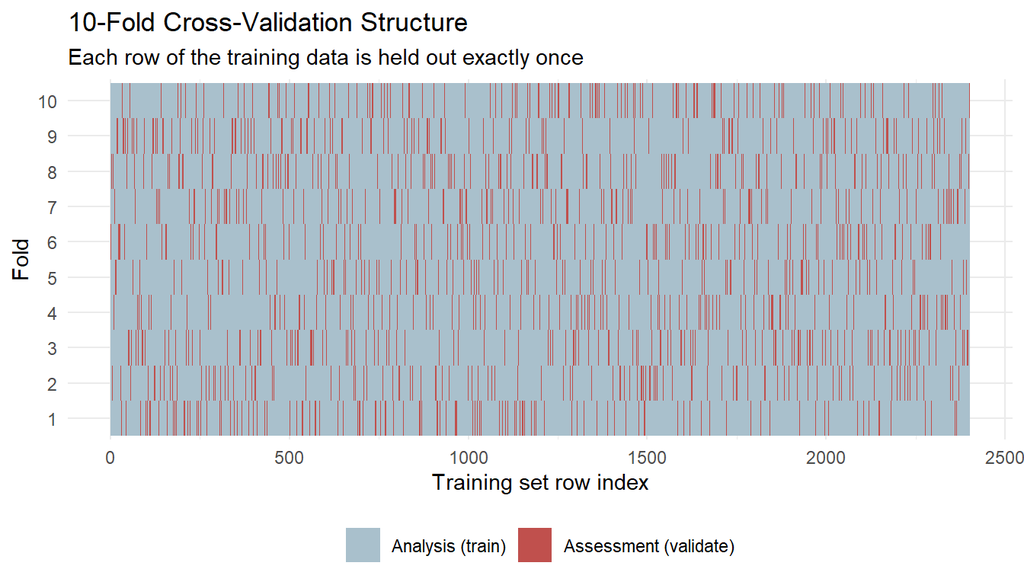

```r
fold_viz <- map_dfr(seq_along(mail_folds$splits), function(i) {
  split <- mail_folds$splits[[i]]
  tibble(
    fold = i,
    row = 1:nrow(mail_train),
    role = if_else(
      row %in% split$in_id,
      "Analysis (train)",
      "Assessment (validate)"
    )
  )
})

ggplot(fold_viz, aes(x = row, y = factor(fold), fill = role)) +
  geom_tile() +
  scale_fill_manual(
    values = c(
      "Analysis (train)" = "#A9C0CC",
      "Assessment (validate)" = "#C0504D"
    )
  ) +
  labs(
    title = "10-Fold Cross-Validation Structure",
    subtitle = "Each row of the training data is held out exactly once",
    x = "Training set row index",
    y = "Fold",
    fill = NULL
  ) +
  theme_minimal(base_size = 11) +
  theme(legend.position = "bottom")
```

## 5.4 Other Resampling Methods (Brief Tour)

```r
# Repeated CV: run 10-fold CV five times with different random splits
repeated_folds <- vfold_cv(mail_train, v = 10, repeats = 5, strata = responded)
cat("Repeated CV total resamples:", nrow(repeated_folds), "\n")
```

```
Repeated CV total resamples: 50
```

```r
# Bootstrap: sample WITH replacement, same size as training data
set.seed(2024)
boot_resamples <- bootstraps(mail_train, times = 25, strata = responded)
cat("Bootstrap resamples:", nrow(boot_resamples), "\n")
```

```
Bootstrap resamples: 25
```

```r
# Validation set: a single held-out chunk carved from the training data
val_set <- validation_split(mail_train, prop = 0.80, strata = responded)
val_set
```

| splits | id |
| --- | --- |
|  | validation |

**NoteWhich Resampling Method When?**

| Method | When to use it | Tradeoff |
| --- | --- | --- |
| **V-fold CV** | Default choice for most marketing datasets | Good balance of bias and computation |
| **Repeated CV** | Smaller datasets where fold-to-fold variability is high | More stable estimates, *v* × *repeats* the compute |
| **Bootstrap** | Want a measure of estimate *uncertainty*, or very small data | Some observations never appear in assessment sets |
| **Validation set** | Very large data where CV is too slow | Only one estimate — less stable than CV |
| **Rolling origin** | Time-ordered data (e.g., monthly campaign cohorts) | Respects temporal order; no shuffling allowed |

## 5.5 Estimating Performance with `fit_resamples()`

This is where it all comes together: fit the workflow on each fold’s analysis set, score it on the assessment set, and average the results.

```r
set.seed(2024)
cv_results <- fit_resamples(
  mail_wf,
  resamples = mail_folds,
  metrics = metric_set(accuracy, roc_auc, sens, spec),
  control = control_resamples(save_pred = TRUE)
)

cv_results
```

| splits | id | .metrics | .notes | .predictions |
| --- | --- | --- | --- | --- |
|  | Fold01 |  |  |  |
|  | Fold02 |  |  |  |
|  | Fold03 |  |  |  |
|  | Fold04 |  |  |  |
|  | Fold05 |  |  |  |
|  | Fold06 |  |  |  |
|  | Fold07 |  |  |  |
|  | Fold08 |  |  |  |
|  | Fold09 |  |  |  |
|  | Fold10 |  |  |  |

```r
collect_metrics(cv_results)
```

| .metric | .estimator | mean | n | std_err | .config |
| --- | --- | --- | --- | --- | --- |
| accuracy | binary | 0.9537500 | 10 | 0.002943003 | pre0_mod0_post0 |
| roc_auc | binary | 0.5902799 | 10 | 0.028832050 | pre0_mod0_post0 |
| sens | binary | 0.0000000 | 10 | 0.000000000 | pre0_mod0_post0 |
| spec | binary | 1.0000000 | 10 | 0.000000000 | pre0_mod0_post0 |

**ImportantComparing the Single Test Set vs. Cross-Validated Estimate**

```r
bind_rows(
  test_preds |>
    metric_set(accuracy, roc_auc)(
      truth = responded,
      estimate = .pred_class,
      .pred_yes
    ) |>
    mutate(source = "Single test set"),
  collect_metrics(cv_results) |>
    filter(.metric %in% c("accuracy", "roc_auc")) |>
    select(.metric, .estimate = mean) |>
    mutate(source = "10-fold CV mean")
) |>
  select(source, .metric, .estimate) |>
  pivot_wider(names_from = source, values_from = .estimate)
```

| .metric | Single test set | 10-fold CV mean |
| --- | --- | --- |
| accuracy | 0.9483333 | 0.9537500 |
| roc_auc | 0.4733262 | 0.5902799 |

The single test-set number is **one draw** from a distribution of possible performance estimates. The cross-validated mean averages over 10 different draws, giving a more stable — and more honest — picture of how the model is likely to perform on new prospects. The standard error reported by `collect_metrics()` tells us how much that estimate might wobble.

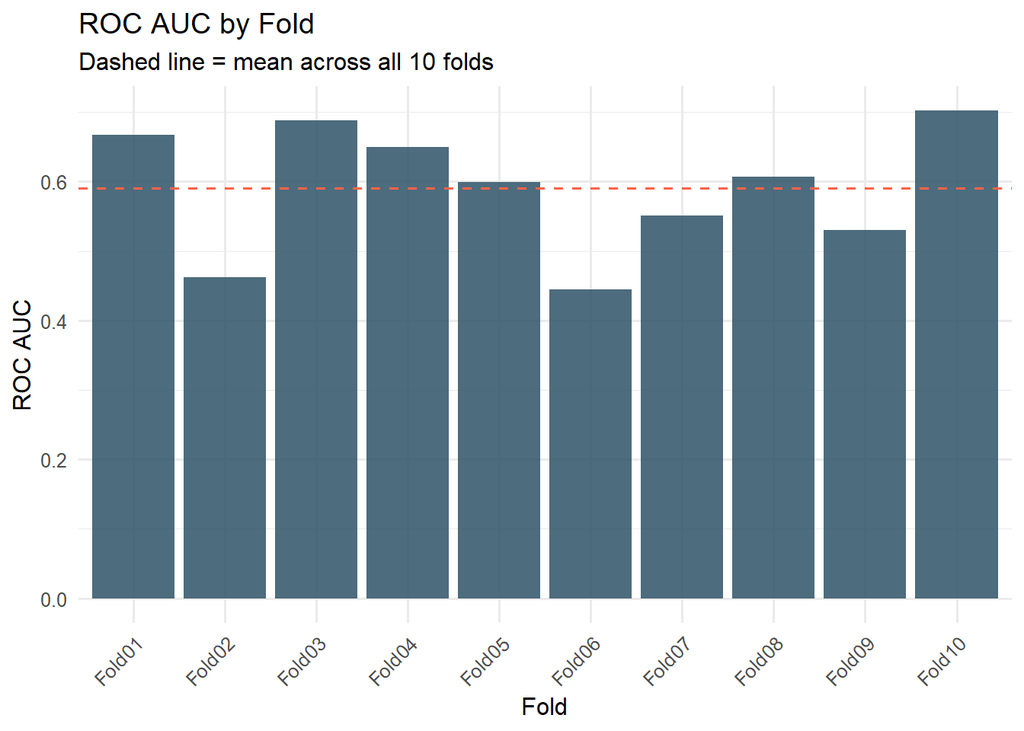

```r
collect_metrics(cv_results, summarize = FALSE) |>
  filter(.metric == "roc_auc") |>
  ggplot(aes(x = id, y = .estimate)) +
  geom_col(fill = "#2E5266", alpha = 0.85) +
  geom_hline(
    aes(yintercept = mean(.estimate)),
    linetype = "dashed",
    color = "tomato"
  ) +
  labs(
    title = "ROC AUC by Fold",
    subtitle = "Dashed line = mean across all 10 folds",
    x = "Fold",
    y = "ROC AUC"
  ) +
  theme_minimal(base_size = 12) +
  theme(axis.text.x = element_text(angle = 45, hjust = 1))
```

## 5.6 Parallel Processing (Conceptual Note)

```r
# Resampling fits the same workflow many times — an embarrassingly parallel task.
# On a multi-core machine, register a parallel backend before fit_resamples():

# install.packages("doParallel")
library(doParallel)
cl <- makePSOCKcluster(parallel::detectCores() - 1)
registerDoParallel(cl)

cv_results <- fit_resamples(mail_wf, resamples = mail_folds)

stopCluster(cl)
```

**Tip**

We don’t run this chunk live in class (it depends on your machine’s core count), but know that `fit_resamples()`, `tune_grid()`, and friends all parallelize automatically once a backend is registered — useful once your resampling scheme + grid search gets large later in the course.

## 5.7 Saving Resampled Objects

```r
# Because we set save_pred = TRUE above, we can pull out every held-out prediction
cv_preds <- collect_predictions(cv_results)
cv_preds |> select(id, .row, responded, .pred_class, .pred_yes) |> head()
```

| id | .row | responded | .pred_class | .pred_yes |
| --- | --- | --- | --- | --- |
| Fold01 | 3 | yes | no | 0.04052661 |
| Fold01 | 31 | no | no | 0.03710792 |
| Fold01 | 33 | no | no | 0.04271608 |
| Fold01 | 44 | no | no | 0.04180505 |
| Fold01 | 69 | no | no | 0.04900048 |
| Fold01 | 82 | no | no | 0.04428243 |

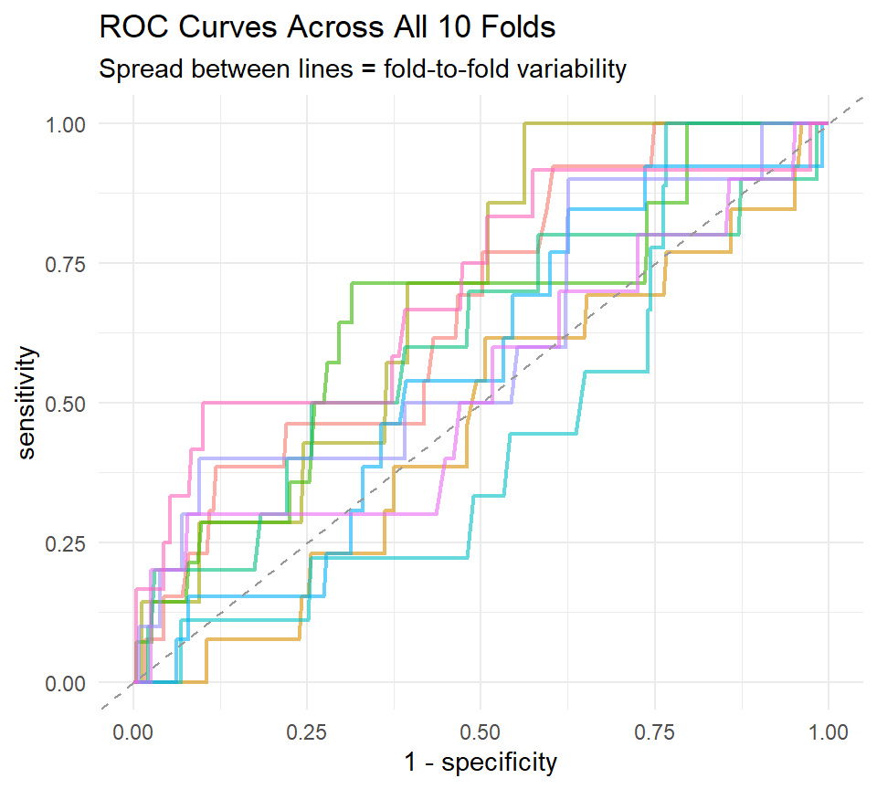

```r
cv_preds |>
  group_by(id) |>
  roc_curve(truth = responded, .pred_yes) |>
  ggplot(aes(x = 1 - specificity, y = sensitivity, color = id)) +
  geom_path(alpha = 0.6, linewidth = 0.8) +
  geom_abline(linetype = "dashed", color = "gray60") +
  labs(
    title = "ROC Curves Across All 10 Folds",
    subtitle = "Spread between lines = fold-to-fold variability",
    color = "Fold"
  ) +
  theme_minimal(base_size = 11) +
  theme(legend.position = "none")
```

**Note**

**Why save predictions?** With `save_pred = TRUE`, we get every out-of-fold prediction back, which lets us build diagnostic plots like the multi-fold ROC curve above, inspect specific misclassified prospects, or build custom metrics — all without ever touching the test set.

# 6 Exercises

## 6.1 ✏️ Exercise 9.1 — Confusion Matrix and Threshold Tradeoff

**Part A — Reading the Confusion Matrix**

Run `conf_mat(test_preds, truth = responded, estimate = .pred_class)` and use the output to answer:

1. **How many customers actually responded (“yes”) and were correctly predicted to respond? What is this cell called?**

   > No customers were correctly predicted as responders. The cell for correctly predicted responders is called true positive (TP).
2. **How many customers actually responded but were predicted “no”? What is this cell called, and what does it cost a marketer**

   > Thirty-one customers responded but were classified as “no.” These are false negatives (FN). Missing these customers means losing potential sales because they would not receive the marketing campaign.
3. **How many customers did not respond but were predicted “yes”? What is this cell called, and what does it cost a marketer**

   > There were no false positives (FP) in this confusion matrix. If false positives occurred, the company would spend money sending mail to customers who would not make a purchase.
4. **In plain English, which type of error is more costly for a direct-mail campaign with a $5 mailing cost and $50 average order value — a false positive or a false negative? Explain your reasoning.**

   > A false negative is more costly in this case. Sending an unnecessary mail costs about $5, but failing to contact a customer who would have responded could lose an average order worth about $50.

```r
conf_mat(test_preds, truth = responded, estimate = .pred_class)
```

```
          Truth
Prediction yes  no
       yes   0   0
       no   31 569
```

**Part B — Threshold Tradeoff**

**Using `test_preds`, compute `precision` and `sens` at the default 0.5 threshold. Now manually create a new `.pred_class` column using a threshold of 0.3 instead (classify as “yes” if `.pred_yes > 0.3`). Recompute both metrics. Which one increased, and why does lowering the threshold have that effect?**

> Neither precision nor sensitivity increased after changing the threshold from 0.5 to 0.3. The largest predicted probability was only about 0.071, so every customer was still classified as “no.” Sensitivity stayed at 0 and precision remained `NA`. A lower threshold often increases sensitivity because more customers are classified as responders. In this dataset, however, every predicted probability was below 0.3, so the threshold change had no effect.

```r
test_preds |>
  metric_set(precision, sens)(
    truth = responded,
    estimate = .pred_class
  )
```

| .metric | .estimator | .estimate |
| --- | --- | --- |
| precision | binary | NA |
| sens | binary | 0 |

```r
test_preds_03 <- test_preds |>
  mutate(
    .pred_class = factor(
      if_else(.pred_yes > 0.3, "yes", "no"),
      levels = levels(responded)
    )
  )

test_preds_03 |>
  metric_set(precision, sens)(
    truth = responded,
    estimate = .pred_class
  )
```

| .metric | .estimator | .estimate |
| --- | --- | --- |
| precision | binary | NA |
| sens | binary | 0 |

## 6.2 ✏️ Exercise 9.2 — ROC/AUC Interpretation and Custom `metric_set()`

Part A — Interpreting AUC

The notebook computed `roc_auc` for the direct-mail response model.

1. **Look up the AUC value from the `roc-curve` chunk. Is it above or below 0.65 (the “usable for targeting” threshold from the callout)?**

   > The AUC is 0.473, which is below the suggested threshold of 0.65.
2. **In plain English, what does an AUC of that value mean? Complete this sentence: “If we randomly pick one customer who responded and one who did not, the model assigns a higher predicted probability to the responder ____% of the time.”**

   > If we randomly pick one customer who responded and one who did not, the model assigns a higher predicted probability to the responder about 47.3% of the time.
3. **The ROC curve plot shows the sensitivity/specificity tradeoff across all thresholds. At what point on the curve would you operate if your campaign budget only allows you to mail the top 10% of prospects?**

   > A point with high specificity is more suitable when only a small number of customers can be contacted. Focusing on customers with the highest predicted probabilities helps keep mailing costs under control.

```r
roc_data <- test_preds |>
  roc_curve(truth = responded, .pred_yes)

auc_val <- test_preds |>
  roc_auc(truth = responded, .pred_yes)

auc_val
```

| .metric | .estimator | .estimate |
| --- | --- | --- |
| roc_auc | binary | 0.4733262 |

Part B — Custom `metric_set()`

**Create a `metric_set()` containing `accuracy`, `roc_auc`, `sens`, `spec`, and `f_meas`. Apply it to `test_preds`. If you had to report just two of these five numbers to a VP of Marketing who is unfamiliar with machine learning metrics, which would you choose and why?**

> ROC AUC and sensitivity are the most informative measures for this model. Accuracy alone is less useful because the response rate is low. ROC AUC summarizes performance across different classification thresholds, while sensitivity shows how many actual responders are identified. Both measures are useful when evaluating a direct-mail campaign.

```r
marketing_metrics <- metric_set(accuracy, roc_auc, sens, spec, f_meas)

marketing_metrics(
  test_preds,
  truth = responded,
  estimate = .pred_class,
  .pred_yes
)
```

| .metric | .estimator | .estimate |
| --- | --- | --- |
| accuracy | binary | 0.9483333 |
| sens | binary | 0.0000000 |
| spec | binary | 1.0000000 |
| f_meas | binary | NA |
| roc_auc | binary | 0.4733262 |

## 6.3 ✏️ Exercise 9.3 — Regression Metric Sensitivity to Outliers

**Add one synthetic “whale” customer to `reg_preds` with `order_value_next = 5000` and `.pred = 200` (a badly missed prediction). Recompute `rmse` and `mae`. Which metric moved more in percentage terms? What does this tell you about choosing RMSE vs. MAE for marketing data with occasional huge orders?**

> Adding one whale customer changed RMSE much more than MAE. One large prediction error affected RMSE strongly because large errors receive more weight. MAE also increased, but much less. When a few customers place unusually large orders, MAE changes less than RMSE and is easier to interpret.

```r
reg_metrics <- metric_set(rmse, rsq, mae)

reg_preds |>
  reg_metrics(
    truth = order_value_next,
    estimate = .pred
  )
```

| .metric | .estimator | .estimate |
| --- | --- | --- |
| rmse | standard | 20.0193095 |
| rsq | standard | 0.5659006 |
| mae | standard | 16.1059669 |

```r
whale_preds <- bind_rows(
  reg_preds,
  tibble(
    order_value_next = 5000,
    .pred = 200
  )
)

metric_set(rmse, mae)(
  whale_preds,
  truth = order_value_next,
  estimate = .pred
)
```

| .metric | .estimator | .estimate |
| --- | --- | --- |
| rmse | standard | 196.81517 |
| mae | standard | 24.06586 |

## 6.4 ✏️ Exercise 9.4 — Multiclass Averaging

Re-run the multiclass `loyalty_tier` example using `estimator = "micro"` instead of the default macro averaging for `sens`. Also run it with `estimator = "macro_weighted"`. Compare all three numbers.

1. **Why might micro-averaging look more favorable when one class (Bronze) is much larger than the others?**

   > Micro-averaging gives more weight to larger classes. Since Bronze has many more customers than the other loyalty tiers, its performance has a stronger influence on the overall result.
2. **Which estimator would you choose if you wanted to ensure that Platinum customers — the rarest and most valuable tier — are not underrepresented in the metric? Explain your reasoning.**

   > Macro averaging is a better choice because every class is treated equally. This allows the Platinum tier to contribute as much as the larger groups, even though it has fewer customers.
3. **In a marketing context, which averaging method is most likely to give a misleadingly optimistic picture of model performance? Why?**

   > Micro-averaging can give a more optimistic result because the largest customer group has the strongest influence on the metric. Strong performance for Bronze customers can make the overall result look better even when smaller groups are predicted less accurately.

```r
multi_preds |>
  metric_set(accuracy, sens)(
    truth = loyalty_tier,
    estimate = .pred_class,
    estimator = "macro"
  )
```

| .metric | .estimator | .estimate |
| --- | --- | --- |
| accuracy | multiclass | 0.4183333 |
| sens | macro | 0.2500000 |

```r
multi_preds |>
  metric_set(accuracy, sens)(
    truth = loyalty_tier,
    estimate = .pred_class,
    estimator = "macro_weighted"
  )
```

| .metric | .estimator | .estimate |
| --- | --- | --- |
| accuracy | multiclass | 0.4183333 |
| sens | macro_weighted | 0.4183333 |

```r
multi_preds |>
  metric_set(accuracy, sens)(
    truth = loyalty_tier,
    estimate = .pred_class,
    estimator = "micro"
  )
```

| .metric | .estimator | .estimate |
| --- | --- | --- |
| accuracy | multiclass | 0.4183333 |
| sens | micro | 0.4183333 |

## 6.5 Appendix

### 6.5.1 Published report on GitHub Pages

https://sora-sky-sora.github.io/W05/Hosoda%20Sora-Reflection%20on%20Ch09.html

### 6.5.2 GitHub Repository

https://github.com/Sora-Sky-Sora/W05